# Weekly Energy Charts

August 15, 2022

[Sign up here to get on our email list](https://docs.google.com/forms/d/e/1FAIpQLSckqeGjUvIlhveVyjmkXe913tzQRLANqPNQzEZTUQD2hQxH8g/viewform?usp=pp_url)

# Featured Stories

## Optimistic take on AB renewables

#### Marc Vermette

A [report from research firm, Rystad Energy](https://oilprice.com/Energy/Energy-General/Canadas-Oil-Province-Will-Soon-Be-A-Renewable-Energy-Leader.html), suggests that Alberta may be poised to become the predominant contributor of renewable power in Canada. But, we’ve got some questions.

To put it bluntly, the conclusions attributed to the study are likely to be mind-boggling to anyone following Alberta’s market closely. Rystad concludes that Alberta will see almost 10 GW of installed renewable capacity before next year, with that total expected to double by 2025 to almost 21 GW. To put that number into perspective, Canada’s (total wind and utlity-scale solar capacity in 2021 was about 16 GW)[https://renewablesassociation.ca/by-the-numbers/].

“Alberta [may] race ahead of Canada’s other provinces and take the top spot in the country’s green table, outpacing Ontario,” the Rystad report said, “The introduction of corporate power purchase agreements (PPAs) in Alberta — a contract for a private operator to sell energy straight to the local grid at a set price — has incentivized developers.” Sure, but that’s not enough to get you from here to there.

Alberta is, without a doubt, moving rapidly to a more renewable-intensive grid. But, there’s something wrong with these numbers. In order to get 21GW of capacity installed by 2025, you’d every project currently in (AESO’s connection queue)[https://www.aeso.ca/grid/projects/connection-project-reporting/] to be completed and connected by 2025, and more. And you’d need somewhere for that power to go a lot of the time since Alberta’s peak loads are, currently, (less than 12GW)[https://www.aeso.ca/assets/Uploads/market-and-system-reporting/2021-Annual-Market-Stats-Final.pdf].

To put these numbers into further perspective, recent AESO forecasts, even in the most accelerated renewables development scenario in their (recent net-zero report)[https://www.aeso.ca/market/net-zero-emissions-pathways/] showed less than 6GW of installed wind and solar capacity by the end of 2025.

We’ll be watching for more detailed reaction to these numbers of the next week or so.

(Original Article)[https://financialpost.com/executive/executive-summary/posthaste-how-the-fossil-fuel-heartland-will-become-canadas-green-energy-leader-in-three-years]

## The Sunny City?

#### [Yousaff Habib](https://www.linkedin.com/in/yousaff-habib-6684891a5/)

On August 9th, Mayor of Chicago, Lori E. Lightfoot announced that, in collaboration with electricity supplier Constellation and Swift Current Energy, the city would purchased renewable energy for all city facilities by 2025. This push has been one of the first of its kind in North America for a city the size of Chicago, and will hopefully inspire others to do the same.

Mayor Lightfoot stated that, “the signing of this agreement demonstrates that the City of Chicago is leading by example and driving high-impact climate action, building the clean energy workforce of the future and equitably distributing meaningful benefits to foster the local clean energy economy for all.”

The project will also serve to [provide renewable energy to other major organizations in the state](https://www.chicago.gov/city/en/depts/mayor/press_room/press_releases/2022/august/Purchase100PercentCleanRenewableEnergy2025.html).

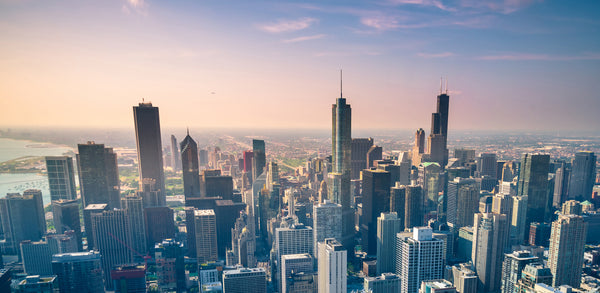

The City of Chicago

The project, dubbed Double Black Diamond Solar, with a capacity of 593 megawatts will be one of the largest solar projects in Illinois. Construction will begin at the end of 2022.

## Is a four-day workweek better for the climate?

#### Erica Beattie

An [article in the Washington Post](https://www.washingtonpost.com/climate-solutions/2022/08/08/4-day-workweek-environment/) argues that reducing the workweek to four days could benefit society, the economy, and even the environment. It mentions [a series of studies](https://research.chalmers.se/en/publication/216709) that have seen a correlation between work time reductions and emissions reduction.

A shortened workweek would directly impact people’s commutes and lifestyle choices, as well as businesses’ energy usage. Transportation is one of the biggest contributors to greenhouse gas emissions, and so cutting back workers’ commuting time has the potential to reduce emissions. This was noticeable during the early months of the pandemic, when the world had to shift to a work-from-home environment. Since then, many have adopted remote or hybrid work models, thereby commuting less. It is important to note that the climate benefits could be reversed should people choose to spend their extra days off travelling, particularly by car or plane. The four-day workweek could also lead to a decrease in energy consumption. For instance, if office buildings are closed for an extra day, that is one less day of using electricity or other energy resources. However, as many people saw during COVID, household energy (and coffee maker!) use increases the more time people spend at home.

The article also argues that fewer work hours can lead to more and more people shifting toward a more sustainable lifestyle. The busier people are, the more likely they are to opt for convenient, time-saving choices, and these tend to be more carbon-intensive. Furthermore, [research](https://www.tandfonline.com/doi/pdf/10.1080/15487733.2005.11907964?needAccess=true) shows that those who work less are more likely to spend their time partaking in traditionally low-carbon activities, like spending time with friends and family.

## Renewable power to make F-150s

#### [Debosree Mukherjee](https://www.linkedin.com/in/debosree-mukherjee/)

Ford Motor Company announced on August 10th that it will be using [renewable energy sources for all vehicles manufactured](https://ca.finance.yahoo.com/news/ford-renewable-energy-sources-vehicles-101310622.html) in its Michigan facilities by 2025. Three plants at Dearborn, Wayne, and Flat Rock build F-150, Mustang, Ranger, and Bronco models. Ford reached a deal with DTE Energy, Michigan’s largest renewable energy producer to power the facilities with renewable energy. It is a big step towards Ford’s goal to power all of its global facilities with renewable energy by 2035. According to this deal, DTE will add 650 MW of new solar energy capacity in the state by 2025. The companies are claiming this to be the largest solar energy purchase from a utility in the US. This deal is expected to cut Ford’s emissions by 600,000 tons.

# Oil

## Weekly Crude Prices

### Feature Crude

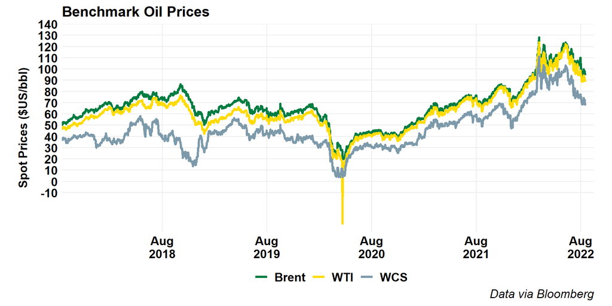

### Alberta Crude

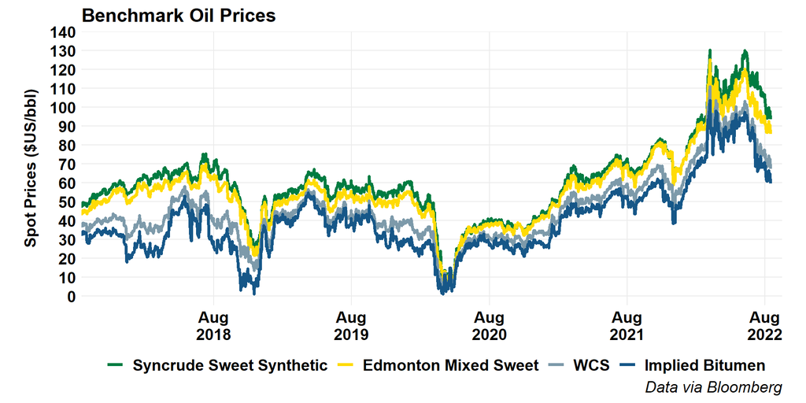

### Alberta Crude (Short)

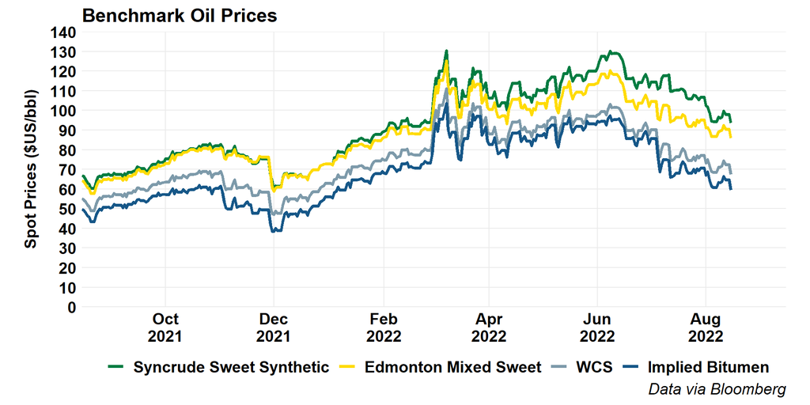

### US Crude

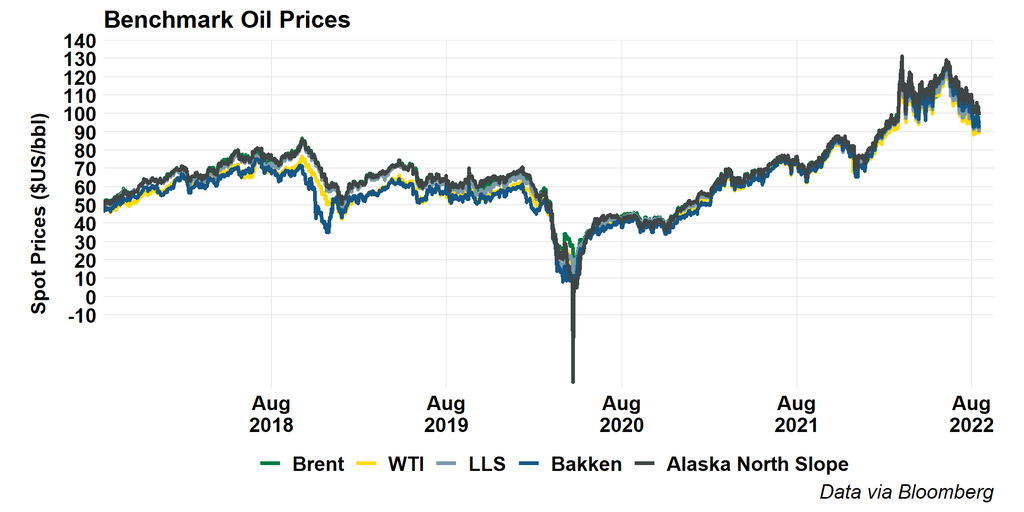

### Global Crude

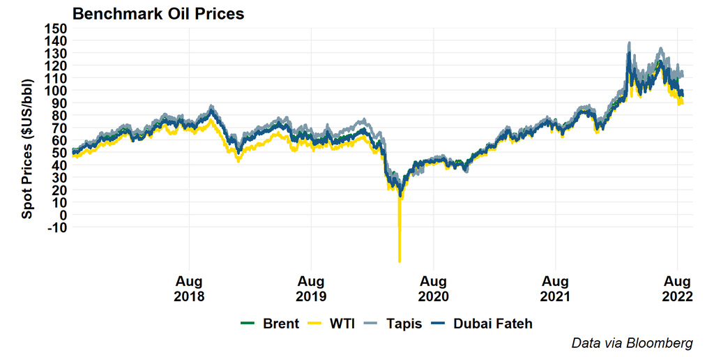

## Oil Price Differentials

### Brent-WTI

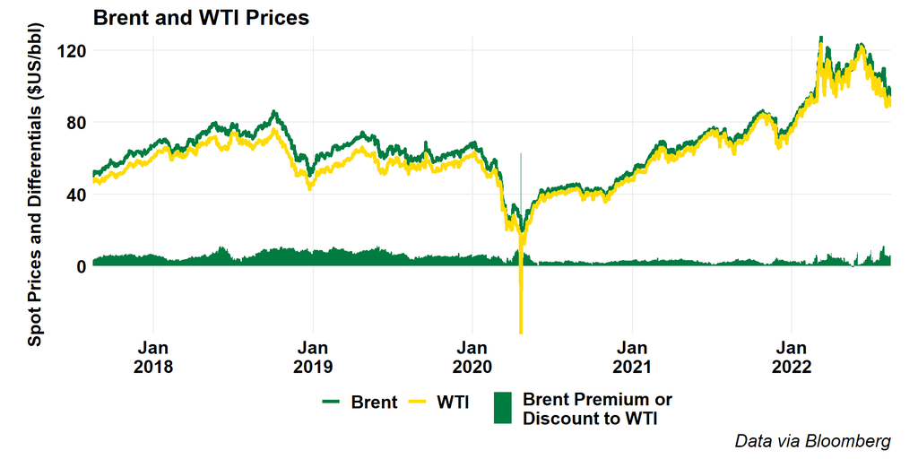

### WTI-WCS

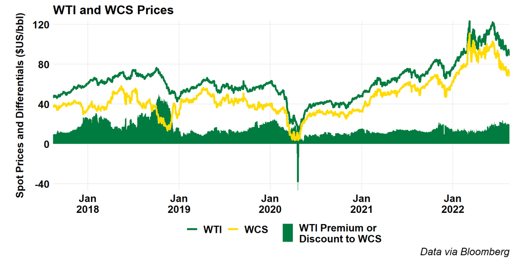

### WTI-WCS (Short)

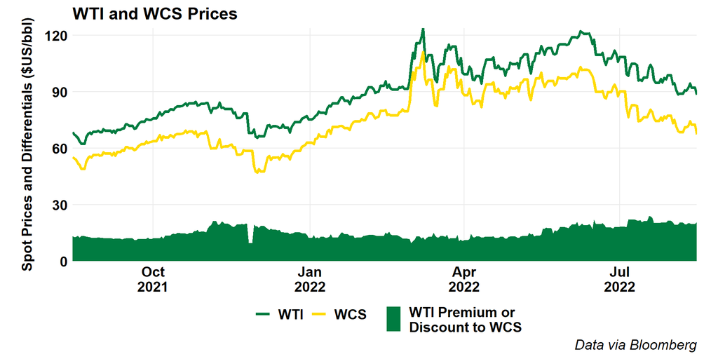

### Maya-WCS

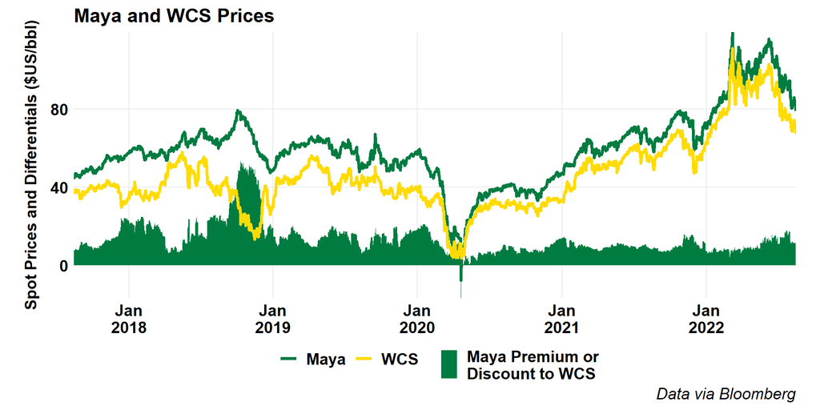

### WTI Cushing vs MEH

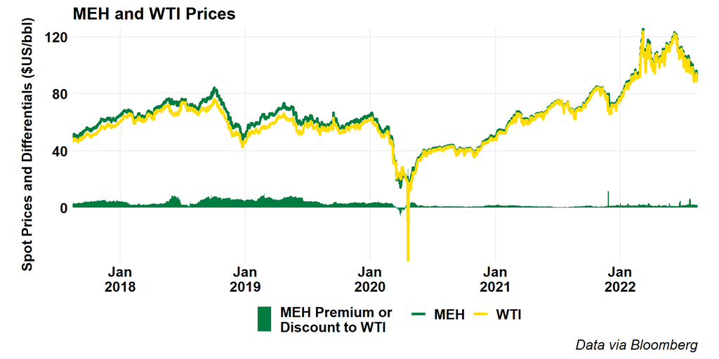

## Forward Curves

### WTI

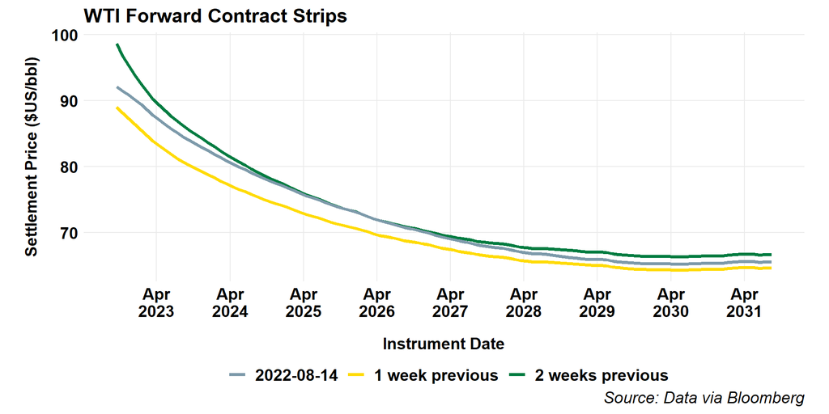

### Brent

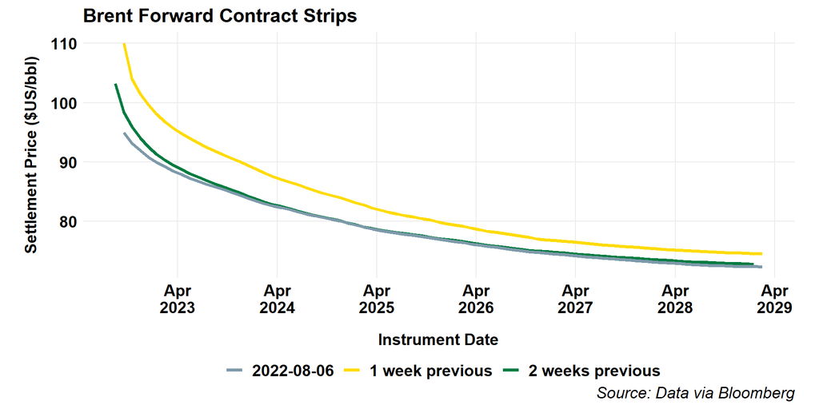

## Canadian Crude Supply and Disposition

### Production

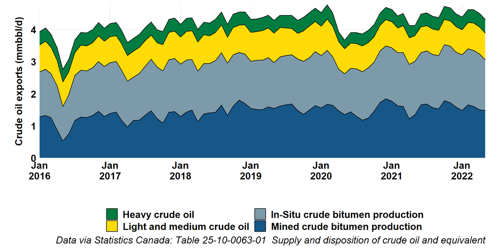

### Imports

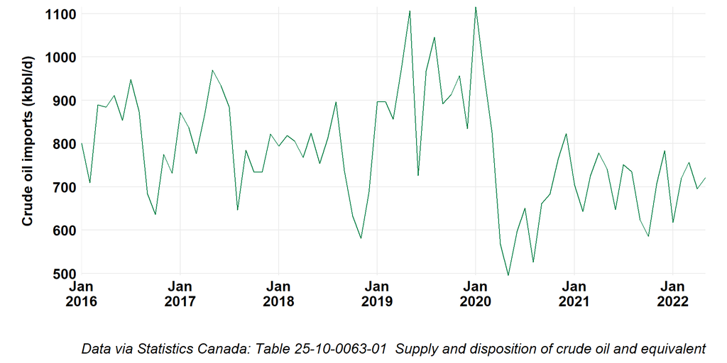

### Exports

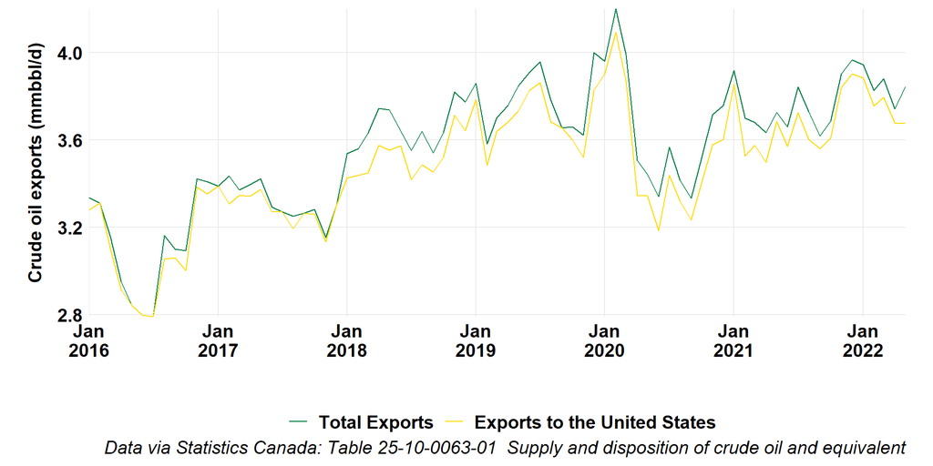

### Rail Exports

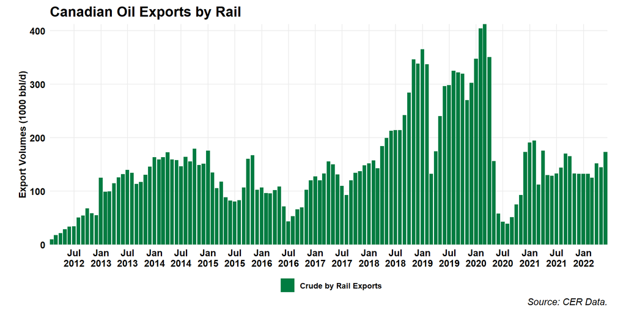

## US Oil

### LTO Production by Play

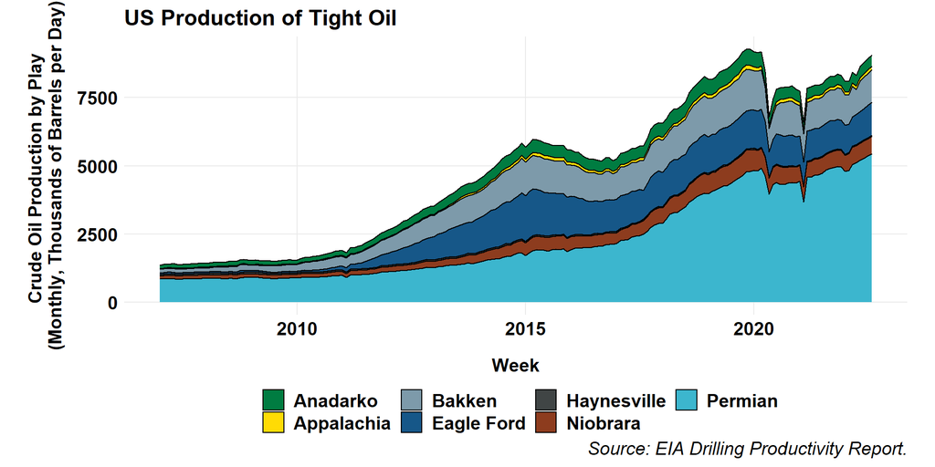

# Refined Products

## Canadian Gasoline Prices

### Map

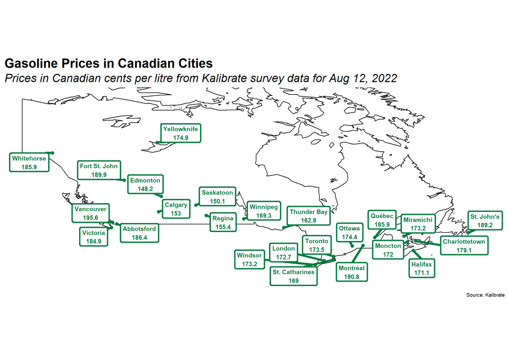

### Historic Gasoline Prices

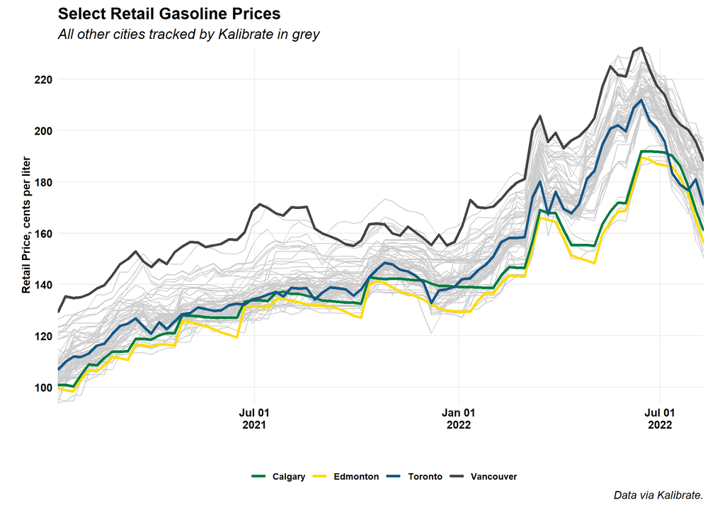

### Historic Gasoline Prices in BTC

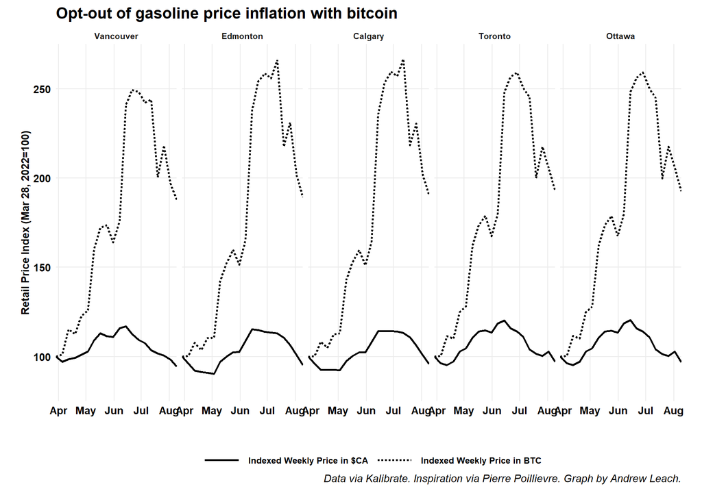

### Historic Diesel Prices

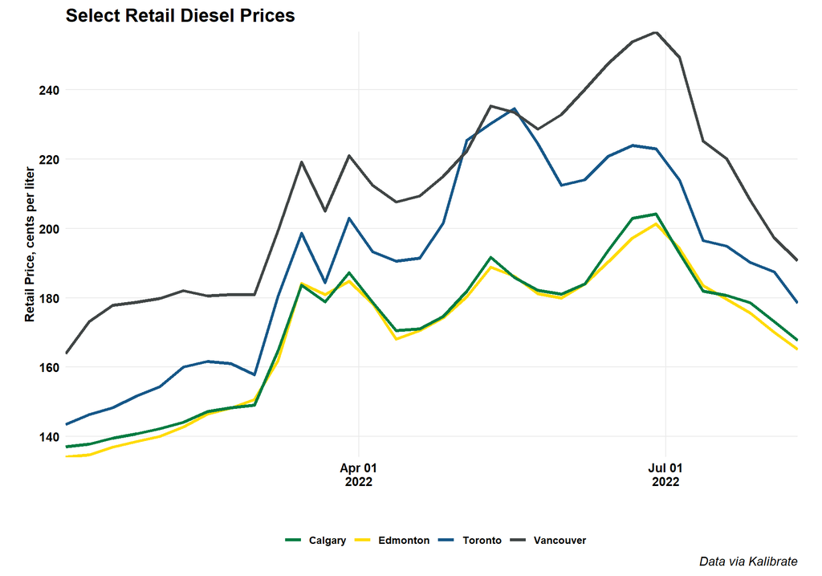

## Canadian Refinery Runs

### Canadian Refinery Runs

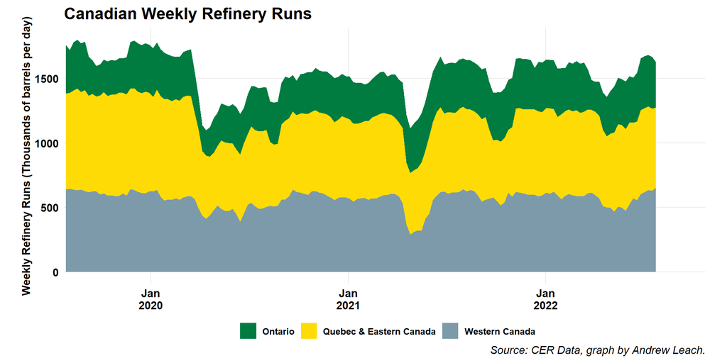

### Western Canada Refinery Runs

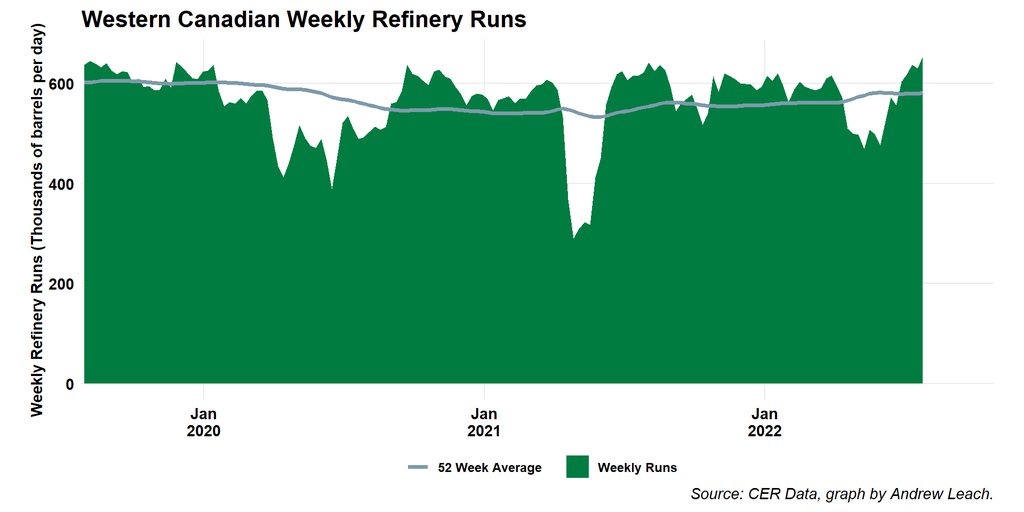

# Natural Gas

## Natural Gas Market Summary

### Feature Gas

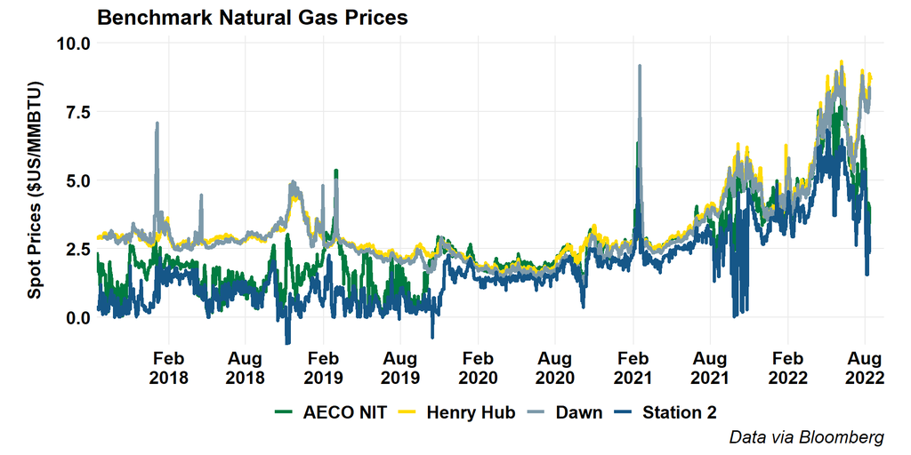

### Feature Gas (Short)

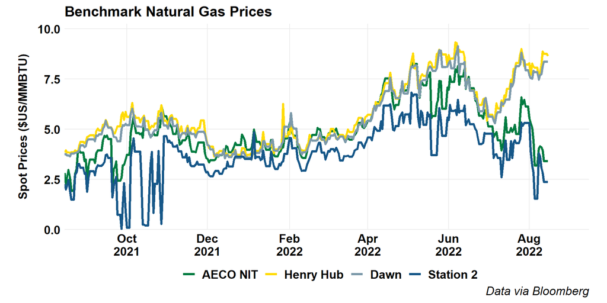

### Global Gas

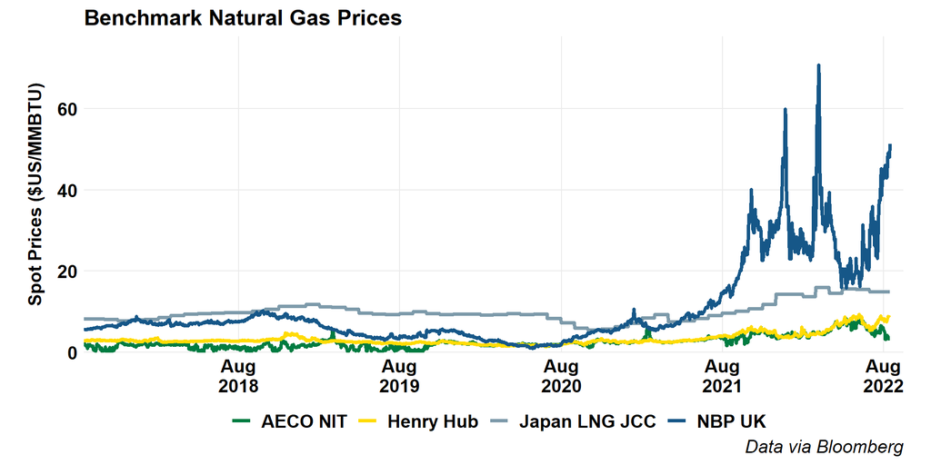

### North American Gas Hubs

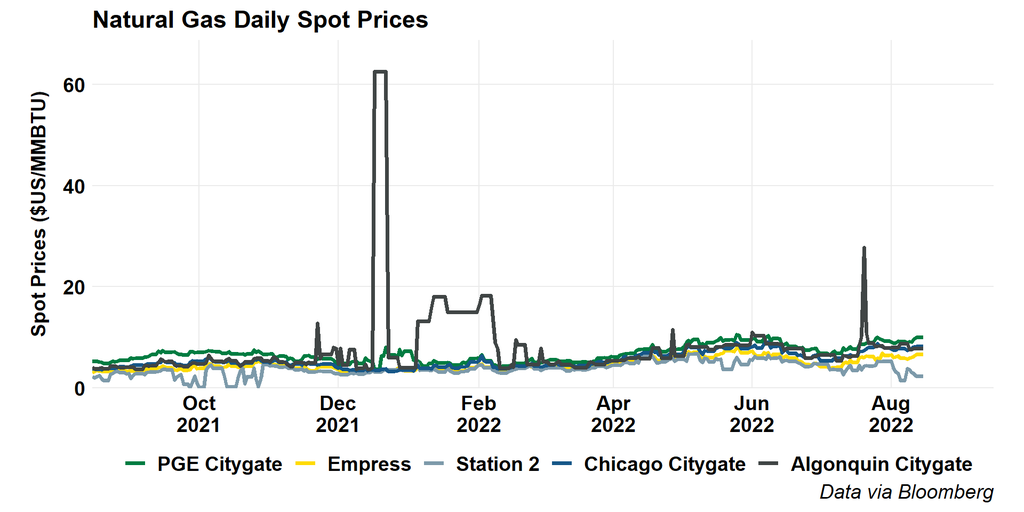

## Forward Prices

### Henry Hub

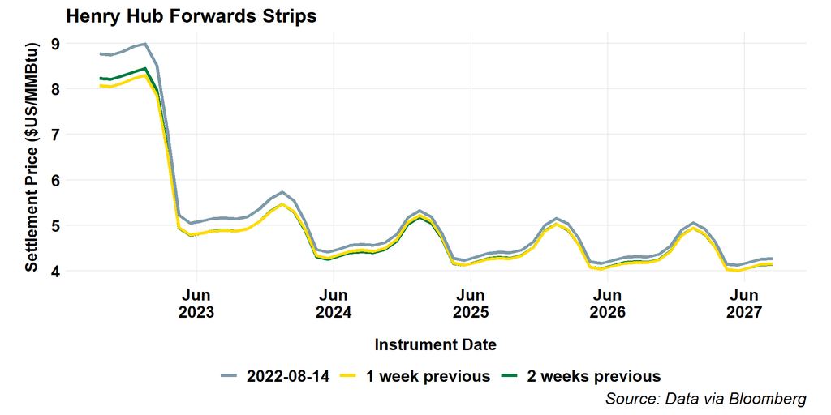

### Alberta (NIT) ($CAD)

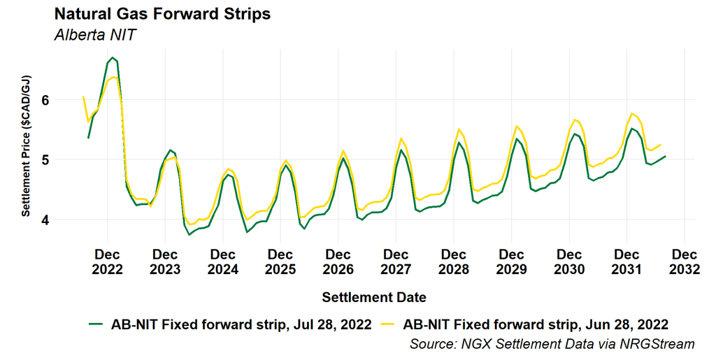